# 모의고사1

### 모의고사1

```
- apriori
- anova(stepwis)
- wordCloud
```

```python
import os
import sys
import pandas as pd
import numpy as np
import seaborn as sns
import matplotlib.pyplot as plt

import warnings
warnings.filterwarnings('ignore')
warnings.warn("once")
%matplotlib inline
#color = sns.color_palette()

# Graph 한글 표시, https://lsh-story.tistory.com/83
import matplotlib
from matplotlib import font_manager, rc
font_name = font_manager.FontProperties(fname="./korean.ttf").get_name()
rc('font',family='AppleGothic')
matplotlib.rcParams['axes.unicode_minus'] = False

print('Python version : ', sys.version)
```

```
Python version :  3.7.4 (default, Aug 13 2019, 15:17:50)
[Clang 4.0.1 (tags/RELEASE_401/final)]
```

# 1. 정형 데이터마이닝 (사용 데이터 : lotto)

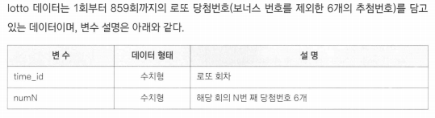

### 1) 연관규칙분석을 수행하기 위해 lotto 데이터셋을 transaction 데이터로 변환하시오.

### 단, 본 분석에서 로또번호가 추첨된 순서는 고려하지 않고 분석을 수행하도록 한다.

### 그리고 변환된 데이터에서 가장 많이 등장한

### 상위 10개의 로또번호를 막대그래프로 출력하고 이에 대해 설명하시오.

```
- 1.1.1) Transaction Data
    - transaction data == n Hot Encoding
    - get_dummies      == 1 Hot Encoding
- 1.1.2) 상위10개 로또번호, 막대그래프
```

### 2) 변환한 데이터에 대해 apriori함수를 사용하여 다음 괄호 안의 조건을 반영하여

### 연관규칙을 생성하고, 이를 ‘rules_1’이라는 변수에 저장하여 결과를 해석하시오.

### (최소 지지도 : 0.002, 최소 신뢰도 : 0.8, 최소조합 항목 수 : 2개, 최대조합 항목 수 : 6개)

### 그리고 도출된 연관규칙들을 향상도를 기준으로 내림차순 정렬하여 상위 30개의 규칙을 확인하고,

### 이를 데이터프레임으로 변환하여 csv파일로 출력하시오.

```
1.2.1) rules_1
1.2.2) 향상도 상위 30개, csv
```

### 3) 생성된 연관규칙 'rules_1'에 대한 정보를 해석하고, Q1)을 통해 확인했을 때

### 가장 많이 추첨된 번호가 우측항에 존재하는 규칙들만을 'rules_most_freq'라는 변수에

### 저장하시오. 그리고 해당 규칙들을 해석하여 인사이트를 도출한 후 서술하시오.

```
- 1.3.1) rules_1 해석
- 1.3.2) rules_most_freq 도출, 해석, 인사이트
```

### 1.1.1) Transaction Data

- transaction data == n Hot Encoding
- get_dummies.... == 1 Hot Encoding

```python
from mlxtend.preprocessing import TransactionEncoder  # Encoder
```

```python
df = pd.read_csv('./dataset/lotto.csv')
df
```

|  | time_id | num1 | num2 | num3 | num4 | num5 | num6 |
| --- | --- | --- | --- | --- | --- | --- | --- |
| 0 | 859 | 8 | 22 | 35 | 38 | 39 | 41 |
| 1 | 858 | 9 | 13 | 32 | 38 | 39 | 43 |
| 2 | 857 | 6 | 10 | 16 | 28 | 34 | 38 |
| 3 | 856 | 10 | 24 | 40 | 41 | 43 | 44 |
| 4 | 855 | 8 | 15 | 17 | 19 | 43 | 44 |
| ... | ... | ... | ... | ... | ... | ... | ... |
| 854 | 5 | 16 | 24 | 29 | 40 | 41 | 42 |
| 855 | 4 | 14 | 27 | 30 | 31 | 40 | 42 |
| 856 | 3 | 11 | 16 | 19 | 21 | 27 | 31 |
| 857 | 2 | 9 | 13 | 21 | 25 | 32 | 42 |
| 858 | 1 | 10 | 23 | 29 | 33 | 37 | 40 |

859 rows × 7 columns

```python
df.drop('time_id', axis=1)
```

|  | num1 | num2 | num3 | num4 | num5 | num6 |
| --- | --- | --- | --- | --- | --- | --- |
| 0 | 8 | 22 | 35 | 38 | 39 | 41 |
| 1 | 9 | 13 | 32 | 38 | 39 | 43 |
| 2 | 6 | 10 | 16 | 28 | 34 | 38 |
| 3 | 10 | 24 | 40 | 41 | 43 | 44 |
| 4 | 8 | 15 | 17 | 19 | 43 | 44 |
| ... | ... | ... | ... | ... | ... | ... |
| 854 | 16 | 24 | 29 | 40 | 41 | 42 |
| 855 | 14 | 27 | 30 | 31 | 40 | 42 |
| 856 | 11 | 16 | 19 | 21 | 27 | 31 |
| 857 | 9 | 13 | 21 | 25 | 32 | 42 |
| 858 | 10 | 23 | 29 | 33 | 37 | 40 |

859 rows × 6 columns

```python
nums = df.drop('time_id', axis=1).values
print(type(nums), nums.shape)
nums
```

```
<class 'numpy.ndarray'> (859, 6)
```

```
array([[ 8, 22, 35, 38, 39, 41],
       [ 9, 13, 32, 38, 39, 43],
       [ 6, 10, 16, 28, 34, 38],
       ...,
       [11, 16, 19, 21, 27, 31],
       [ 9, 13, 21, 25, 32, 42],
       [10, 23, 29, 33, 37, 40]])
```

```python
# TransactionEncoder
te = TransactionEncoder()
buf = te.fit(nums).transform(nums)

# array -> df
dft = pd.DataFrame(buf, columns=te.columns_)  # dft = df_transaction
print(dft.shape)
dft
```

```
(859, 45)
```

|  | 1 | 2 | 3 | 4 | 5 | 6 | 7 | 8 | 9 | 10 | ... | 36 | 37 | 38 | 39 | 40 | 41 | 42 | 43 | 44 | 45 |
| --- | --- | --- | --- | --- | --- | --- | --- | --- | --- | --- | --- | --- | --- | --- | --- | --- | --- | --- | --- | --- | --- |
| 0 | False | False | False | False | False | False | False | True | False | False | ... | False | False | True | True | False | True | False | False | False | False |
| 1 | False | False | False | False | False | False | False | False | True | False | ... | False | False | True | True | False | False | False | True | False | False |
| 2 | False | False | False | False | False | True | False | False | False | True | ... | False | False | True | False | False | False | False | False | False | False |
| 3 | False | False | False | False | False | False | False | False | False | True | ... | False | False | False | False | True | True | False | True | True | False |
| 4 | False | False | False | False | False | False | False | True | False | False | ... | False | False | False | False | False | False | False | True | True | False |
| ... | ... | ... | ... | ... | ... | ... | ... | ... | ... | ... | ... | ... | ... | ... | ... | ... | ... | ... | ... | ... | ... |
| 854 | False | False | False | False | False | False | False | False | False | False | ... | False | False | False | False | True | True | True | False | False | False |
| 855 | False | False | False | False | False | False | False | False | False | False | ... | False | False | False | False | True | False | True | False | False | False |
| 856 | False | False | False | False | False | False | False | False | False | False | ... | False | False | False | False | False | False | False | False | False | False |
| 857 | False | False | False | False | False | False | False | False | True | False | ... | False | False | False | False | False | False | True | False | False | False |
| 858 | False | False | False | False | False | False | False | False | False | True | ... | False | True | False | False | True | False | False | False | False | False |

859 rows × 45 columns

### * Memo

r, mlxtend는 transaction 전처리가 필요하지만, apyori package는 필요 없음 (그래도 일단 구현함)

### 1.1.2) 상위10개 로또번호, 막대그래프

```python
df
```

|  | time_id | num1 | num2 | num3 | num4 | num5 | num6 |
| --- | --- | --- | --- | --- | --- | --- | --- |
| 0 | 859 | 8 | 22 | 35 | 38 | 39 | 41 |
| 1 | 858 | 9 | 13 | 32 | 38 | 39 | 43 |
| 2 | 857 | 6 | 10 | 16 | 28 | 34 | 38 |
| 3 | 856 | 10 | 24 | 40 | 41 | 43 | 44 |
| 4 | 855 | 8 | 15 | 17 | 19 | 43 | 44 |
| ... | ... | ... | ... | ... | ... | ... | ... |
| 854 | 5 | 16 | 24 | 29 | 40 | 41 | 42 |
| 855 | 4 | 14 | 27 | 30 | 31 | 40 | 42 |
| 856 | 3 | 11 | 16 | 19 | 21 | 27 | 31 |
| 857 | 2 | 9 | 13 | 21 | 25 | 32 | 42 |
| 858 | 1 | 10 | 23 | 29 | 33 | 37 | 40 |

859 rows × 7 columns

```python
dfm = df.melt('time_id')  # df_melt, 고정행 제외값 merge(variable,value형태로)
dfm
```

|  | time_id | variable | value |
| --- | --- | --- | --- |
| 0 | 859 | num1 | 8 |
| 1 | 858 | num1 | 9 |
| 2 | 857 | num1 | 6 |
| 3 | 856 | num1 | 10 |
| 4 | 855 | num1 | 8 |
| ... | ... | ... | ... |
| 5149 | 5 | num6 | 42 |
| 5150 | 4 | num6 | 42 |
| 5151 | 3 | num6 | 31 |
| 5152 | 2 | num6 | 42 |
| 5153 | 1 | num6 | 40 |

5154 rows × 3 columns

```python
dfg = dfm.groupby('value')[['variable']].count() # df_groupby
print(type(dfg),dfg.shape)
dfg.head()
```

```
<class 'pandas.core.frame.DataFrame'> (45, 1)
```

| value | variable |
| --- | --- |
| 1 | 122 |
| 2 | 112 |
| 3 | 111 |
| 4 | 115 |
| 5 | 119 |

```python
df10 = dfg.sort_values(by='variable', ascending=False)[:10].reset_index()
df10
```

|  | value | variable |
| --- | --- | --- |
| 0 | 34 | 134 |
| 1 | 40 | 126 |
| 2 | 27 | 126 |
| 3 | 43 | 125 |
| 4 | 20 | 124 |
| 5 | 17 | 123 |
| 6 | 12 | 123 |
| 7 | 1 | 122 |
| 8 | 14 | 122 |
| 9 | 10 | 122 |

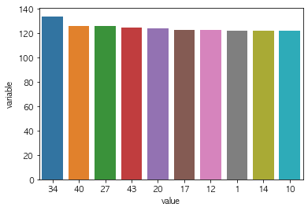

```python
sns.barplot(data = df10,
            x = 'value',
            y = 'variable',
            order = df10['value']) #order미지정시, x의 오름차순 정렬됨(1,10,12...)
```